# Exploratory Data Analysis

### EDA when target variable is categorical variable

Let’s do the EDA when the target variable is categorical. When the categorical variable US is the target variable, the relationship between the target variable and the predictor is examined.

#### Cases where predictors are numeric variable

`relate()` shows the relationship between the target variable and the predictor. The following example shows the relationship between Sales and the target variable US. The predictor Sales is a numeric variable. In this case, the descriptive statistics are shown for each level of the target variable.

```r
# If the variable of interest is a numarical variable
cat_num <- relate(categ, Sales)
cat_num
# A tibble: 3 x 27
  variable US        n    na  mean    sd se_mean   IQR skewness kurtosis   p00
  <chr>    <fct> <dbl> <dbl> <dbl> <dbl>   <dbl> <dbl>    <dbl>    <dbl> <dbl>
1 Sales    No      142     0  6.82  2.60   0.218  3.44   0.323    0.808   0
2 Sales    Yes     258     0  7.87  2.88   0.179  4.23   0.0760  -0.326   0.37
3 Sales    total   400     0  7.50  2.82   0.141  3.93   0.186   -0.0809  0
# ... with 16 more variables: p01 <dbl>, p05 <dbl>, p10 <dbl>, p20 <dbl>,
#   p25 <dbl>, p30 <dbl>, p40 <dbl>, p50 <dbl>, p60 <dbl>, p70 <dbl>,
#   p75 <dbl>, p80 <dbl>, p90 <dbl>, p95 <dbl>, p99 <dbl>, p100 <dbl>
summary(cat_num)
   variable             US          n               na         mean
 Length:3           No   :1   Min.   :142.0   Min.   :0   Min.   :6.823
 Class :character   Yes  :1   1st Qu.:200.0   1st Qu.:0   1st Qu.:7.160
 Mode  :character   total:1   Median :258.0   Median :0   Median :7.496
                              Mean   :266.7   Mean   :0   Mean   :7.395
                              3rd Qu.:329.0   3rd Qu.:0   3rd Qu.:7.682
                              Max.   :400.0   Max.   :0   Max.   :7.867
       sd           se_mean            IQR           skewness
 Min.   :2.603   Min.   :0.1412   Min.   :3.442   Min.   :0.07603
 1st Qu.:2.713   1st Qu.:0.1602   1st Qu.:3.686   1st Qu.:0.13080
 Median :2.824   Median :0.1791   Median :3.930   Median :0.18556
 Mean   :2.768   Mean   :0.1796   Mean   :3.866   Mean   :0.19489
 3rd Qu.:2.851   3rd Qu.:0.1988   3rd Qu.:4.077   3rd Qu.:0.25432
 Max.   :2.877   Max.   :0.2184   Max.   :4.225   Max.   :0.32308
    kurtosis             p00              p01              p05
 Min.   :-0.32638   Min.   :0.0000   Min.   :0.4675   Min.   :3.147
 1st Qu.:-0.20363   1st Qu.:0.0000   1st Qu.:0.6868   1st Qu.:3.148
 Median :-0.08088   Median :0.0000   Median :0.9062   Median :3.149
 Mean   : 0.13350   Mean   :0.1233   Mean   :1.0072   Mean   :3.183
 3rd Qu.: 0.36344   3rd Qu.:0.1850   3rd Qu.:1.2771   3rd Qu.:3.200
 Max.   : 0.80776   Max.   :0.3700   Max.   :1.6480   Max.   :3.252
      p10             p20             p25             p30
 Min.   :3.917   Min.   :4.754   Min.   :5.080   Min.   :5.306
 1st Qu.:4.018   1st Qu.:4.910   1st Qu.:5.235   1st Qu.:5.587
 Median :4.119   Median :5.066   Median :5.390   Median :5.867
 Mean   :4.073   Mean   :5.051   Mean   :5.411   Mean   :5.775
 3rd Qu.:4.152   3rd Qu.:5.199   3rd Qu.:5.576   3rd Qu.:6.010
 Max.   :4.184   Max.   :5.332   Max.   :5.763   Max.   :6.153
      p40             p50             p60             p70
 Min.   :5.994   Min.   :6.660   Min.   :7.496   Min.   :7.957
 1st Qu.:6.301   1st Qu.:7.075   1st Qu.:7.787   1st Qu.:8.386
 Median :6.608   Median :7.490   Median :8.078   Median :8.815
 Mean   :6.506   Mean   :7.313   Mean   :8.076   Mean   :8.740
 3rd Qu.:6.762   3rd Qu.:7.640   3rd Qu.:8.366   3rd Qu.:9.132
 Max.   :6.916   Max.   :7.790   Max.   :8.654   Max.   :9.449
      p75             p80              p90              p95
 Min.   :8.523   Min.   : 8.772   Min.   : 9.349   Min.   :11.28
 1st Qu.:8.921   1st Qu.: 9.265   1st Qu.:10.325   1st Qu.:11.86
 Median :9.320   Median : 9.758   Median :11.300   Median :12.44
 Mean   :9.277   Mean   : 9.665   Mean   :10.795   Mean   :12.08
 3rd Qu.:9.654   3rd Qu.:10.111   3rd Qu.:11.518   3rd Qu.:12.49
 Max.   :9.988   Max.   :10.464   Max.   :11.736   Max.   :12.54
      p99             p100
 Min.   :13.64   Min.   :14.90
 1st Qu.:13.78   1st Qu.:15.59
 Median :13.91   Median :16.27
 Mean   :13.86   Mean   :15.81
 3rd Qu.:13.97   3rd Qu.:16.27
 Max.   :14.03   Max.   :16.27
```

The `relate class` object created with`relate()` visualizes the relationship between the target variable and the predictor with `plot()`. The relationship between US and Sales is represented by a density plot.

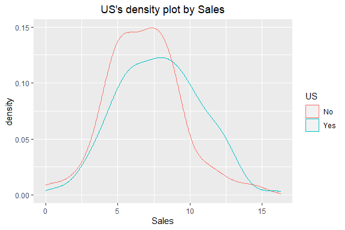

```r
plot(cat_num)
```

#### Cases where predictors are categorical variable

The following example shows the relationship between `ShelveLoc` and the target variable `US`. The predictor, ShelveLoc, is a categorical variable. In this case, we show the `contigency table` of two variables. The `summary()` function also performs an `independence test` on the contigency table.

```r
# If the variable of interest is a categorical variable
cat_cat <- relate(categ, ShelveLoc)
cat_cat
     ShelveLoc
US    Bad Good Medium
  No   34   24     84
  Yes  62   61    135
summary(cat_cat)
Call: xtabs(formula = formula_str, data = data, addNA = TRUE)
Number of cases in table: 400
Number of factors: 2
Test for independence of all factors:
    Chisq = 2.7397, df = 2, p-value = 0.2541
```

`plot()` visualizes the relationship between the target variable and the predictor. The relationship between `US` and `ShelveLoc` is represented by a `mosaics plot`.

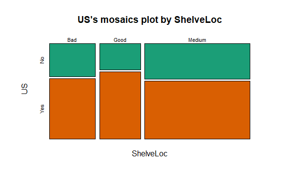

```r
plot(cat_cat)
```

### EDA when target variable is numerical variable

Let’s do the EDA when the target variable is numeric. When the numeric variable Sales is the target variable, the relationship between the target variable and the predictor is examined.

```r
# If the variable of interest is a numarical variable
num <- target_by(carseats, Sales)
```

#### Cases where predictors are numeric variable

The following example shows the relationship between `Price` and the target variable `Sales`. Price, a predictor, is a numeric variable. In this case, we show the result of `simple regression model` of `target ~ predictor` relation. The `summary()` function represents the details of the model.

```r
# If the variable of interest is a numarical variable
num_num <- relate(num, Price)
num_num

Call:
lm(formula = formula_str, data = data)

Coefficients:
(Intercept)        Price
   13.64192     -0.05307
summary(num_num)

Call:
lm(formula = formula_str, data = data)

Residuals:
    Min      1Q  Median      3Q     Max
-6.5224 -1.8442 -0.1459  1.6503  7.5108

Coefficients:
             Estimate Std. Error t value Pr(>|t|)
(Intercept) 13.641915   0.632812  21.558   <2e-16 ***
Price       -0.053073   0.005354  -9.912   <2e-16 ***
---
Signif. codes:  0 '***' 0.001 '**' 0.01 '*' 0.05 '.' 0.1 ' ' 1

Residual standard error: 2.532 on 398 degrees of freedom
Multiple R-squared:  0.198, Adjusted R-squared:  0.196
F-statistic: 98.25 on 1 and 398 DF,  p-value: < 2.2e-16
```

`plot()` visualizes the relationship between the target variable and the predictor. The relationship between Sales and Price is repersented as a scatter plot. The plot on the left represents the scatter plot of Sales and Price and the confidence interval of the regression line and the regression line. The plot on the right represents the relationship between the original data and the predicted value of the linear model as a scatter plot. If there is a linear relationship between the two variables, the observations will converge on the red diagonal in the scatter plot.

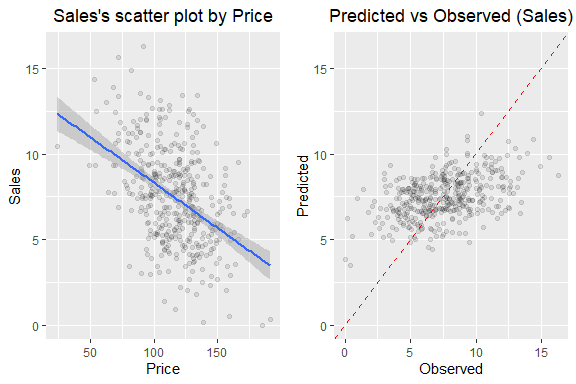

```r
plot(num_num)
`geom_smooth()` using formula 'y ~ x'
```

The scatter plot of the data with a large number of observations is output as overlapping points. This makes it difficult to judge the relationship between the two variables. It also takes a long time to perform the visualization. In this case, the above problem can be solved by hexabin plot.

In `plot()`, the hex_thres argument provides a basis for drawing hexabin plots. For data with more than this number of observations, draw a hexabin plot.

Next, draw a hexabin plot with `plot()` not a scatter plot, specifying 350 for the hex_thres argument. This is because the number of observations is 400.

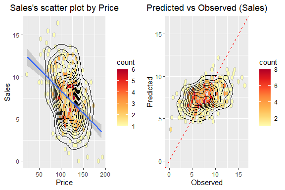

```r
plot(num_num, hex_thres = 350)
`geom_smooth()` using formula 'y ~ x'
```

#### Cases where predictors are categorical variable

The following example shows the relationship between `ShelveLoc` and the target variable `Sales`. The predictor, ShelveLoc, is a categorical variable. It shows the result of performing `one-way ANOVA` of `target ~ predictor` relation. The results are represented in terms of an analysis of variance. The `summary()` function also shows the `regression coefficients` for each level of the predictor. In other words, it shows detailed information of `simple regression analysis` of `target ~ predictor` relation.

```r
# If the variable of interest is a categorical variable
num_cat <- relate(num, ShelveLoc)
num_cat
Analysis of Variance Table

Response: Sales
           Df Sum Sq Mean Sq F value    Pr(>F)
ShelveLoc   2 1009.5  504.77   92.23 < 2.2e-16 ***
Residuals 397 2172.7    5.47
---
Signif. codes:  0 '***' 0.001 '**' 0.01 '*' 0.05 '.' 0.1 ' ' 1
summary(num_cat)

Call:
lm(formula = formula(formula_str), data = data)

Residuals:
    Min      1Q  Median      3Q     Max
-7.3066 -1.6282 -0.0416  1.5666  6.1471

Coefficients:
                Estimate Std. Error t value Pr(>|t|)
(Intercept)       5.5229     0.2388  23.131  < 2e-16 ***
ShelveLocGood     4.6911     0.3484  13.464  < 2e-16 ***
ShelveLocMedium   1.7837     0.2864   6.229  1.2e-09 ***
---
Signif. codes:  0 '***' 0.001 '**' 0.01 '*' 0.05 '.' 0.1 ' ' 1

Residual standard error: 2.339 on 397 degrees of freedom
Multiple R-squared:  0.3172,    Adjusted R-squared:  0.3138
F-statistic: 92.23 on 2 and 397 DF,  p-value: < 2.2e-16
```

`plot()` visualizes the relationship between the target variable and the predictor. The relationship between `Sales` and `ShelveLoc` is represented by a `box plot`.

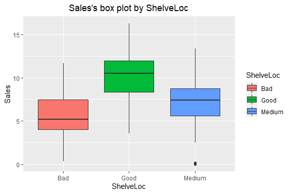

```r
plot(num_cat)
```

## Creating an EDA report using `eda_report()`

`eda_report()` performs EDA on all variables of the data frame or object (`tbl_df`,`tbl`, etc.) that inherits the data frame.

`eda_report()` creates an EDA report in two forms:

- pdf file based on Latex
- html file

The contents of the report are as follows.:

The following will create an EDA report for `carseats`. The file format is pdf, and the file name is `EDA_Report.pdf`.

```r
carseats %>%
  eda_report(target = Sales)
```

The following generates an HTML-formatted report named `EDA.html`.

```r
carseats %>%
  eda_report(target = Sales, output_format = "html", output_file = "EDA.html")
```

The EDA report is an automated report to assist in the EDA process. Design the data analysis scenario with reference to the report results.

### EDA report contents

#### Contents of pdf file

- The cover of the report is shown in the following figure.

[figure not shown]

EDA report cover

- The report’s argenda is shown in the following figure.

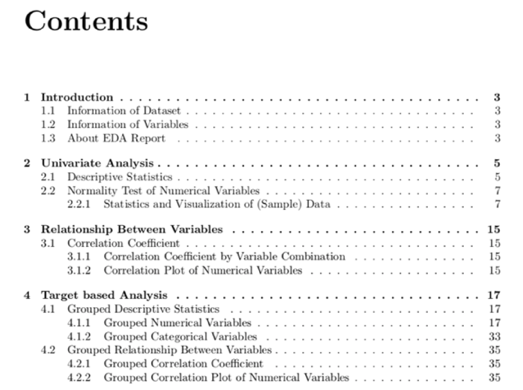

EDA Report Contents

- Much information is represented in tables in the report. An example of the table is shown in the following figure.

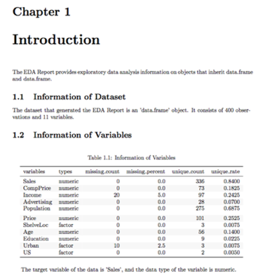

Example EDA report table

- In the EDA report, the normality test content includes visualization results. The result is shown in the following figure.

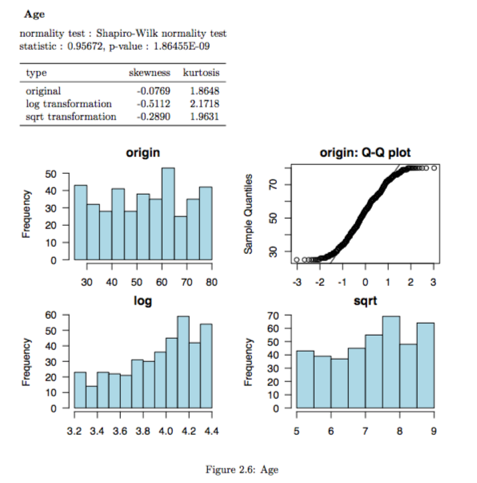

Normality test information in EDA reports

- Correlation information in EDA reports includes visualization results. The result is shown in the following figure.

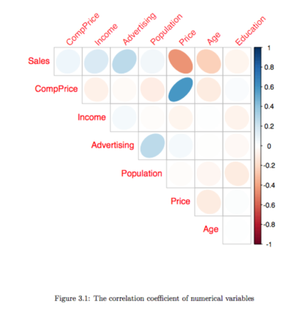

Correlation information in EDA reports

- In EDA reports, information on linear relationships includes tables and visualization results. The result is shown in the following figure.

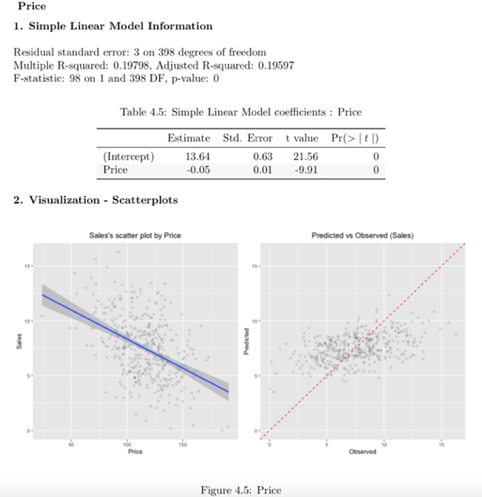

Linear relationship information in EDA reports

- In EDA reports, ANOVA information includes tables and visualization results. The result is shown in the following figure.

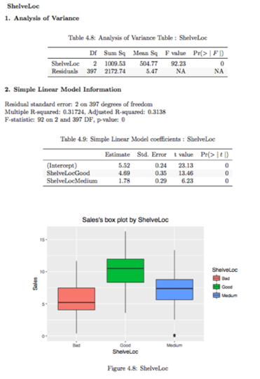

Information about ANOVA in EDA reports

#### Contents of html file

- The title and contents of the report are shown in the following figure.

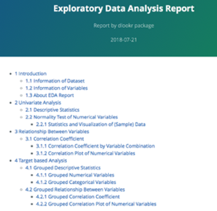

EDA report titles and table of contents

- Much information is represented in tables in the report. An example of a table in an html file is shown in the following figure.

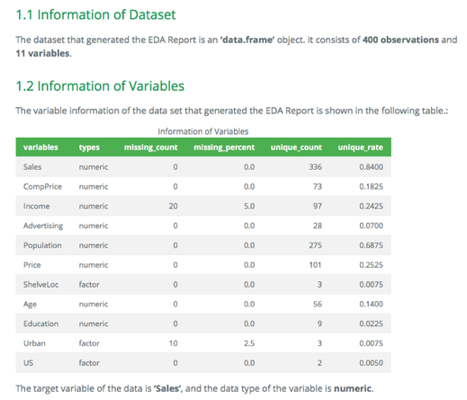

EDA report table example (Web)

- In EDA reports, normality test information includes visualization results. The result of the html file is shown in the following figure.

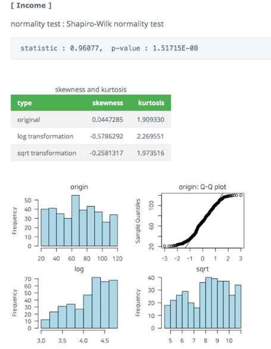

EDA Report Normality Test Information (Web)

## Exploratory data analysis for tables in DBMS

EDA function for table of DBMS supports In-database mode that performs SQL operations on the DBMS side. If the size of the data is large, using In-database mode is faster.

It is difficult to obtain anomaly or to implement the sampling-based algorithm in SQL of DBMS. So some functions do not yet support In-database mode. In this case, it is performed in In-memory mode in which table data is brought to R side and calculated. In this case, if the data size is large, the execution speed may be slow. It supports the collect_size argument, which allows you to import the specified number of samples of data into R.

- In-database support fuctions
  - none
- In-database not support fuctions
  - `normality()`
  - `plot_normality()`
  - `correlate()`
  - `plot_correlate()`
  - `describe()`
  - `eda_report()`

### Preparing table data

Copy the `carseats` data frame to the SQLite DBMS and create it as a table named `TB_CARSEATS`. Mysql/MariaDB, PostgreSQL, Oracle DBMS, etc. are also available for your environment.

```r
if (!require(DBI)) install.packages('DBI')
if (!require(RSQLite)) install.packages('RSQLite')
if (!require(dplyr)) install.packages('dplyr')
if (!require(dbplyr)) install.packages('dbplyr')

library(dplyr)

carseats <- ISLR::Carseats
carseats[sample(seq(NROW(carseats)), 20), "Income"] <- NA
carseats[sample(seq(NROW(carseats)), 5), "Urban"] <- NA

# connect DBMS
con_sqlite <- DBI::dbConnect(RSQLite::SQLite(), ":memory:")

# copy carseats to the DBMS with a table named TB_CARSEATS
copy_to(con_sqlite, carseats, name = "TB_CARSEATS", overwrite = TRUE)
```

### Calculating descriptive statistics of numerical column of table in the DBMS

Use `dplyr::tbl()` to create a tbl_dbi object, then use it as a data frame object. That is, the data argument of all EDA function is specified as tbl_dbi object instead of data frame object.

```r
# Positive values select variables
con_sqlite %>%
  tbl("TB_CARSEATS") %>%
  describe(Sales, CompPrice, Income)
Warning: `cols` is now required when using unnest().
Please use `cols = c(statistic)`
# A tibble: 3 x 26
  variable     n    na   mean    sd se_mean   IQR skewness kurtosis   p00    p01
  <chr>    <int> <int>  <dbl> <dbl>   <dbl> <dbl>    <dbl>    <dbl> <dbl>  <dbl>
1 Sales      400     0   7.50  2.82   0.141  3.93   0.186   -0.0809     0  0.906
2 CompPri~   400     0 125.   15.3    0.767 20     -0.0428   0.0417    77 89.0
3 Income     380    20  68.8  28.0    1.44  47.2    0.0641  -1.08      21 21.8
# ... with 15 more variables: p05 <dbl>, p10 <dbl>, p20 <dbl>, p25 <dbl>,
#   p30 <dbl>, p40 <dbl>, p50 <dbl>, p60 <dbl>, p70 <dbl>, p75 <dbl>,
#   p80 <dbl>, p90 <dbl>, p95 <dbl>, p99 <dbl>, p100 <dbl>

# Negative values to drop variables, and In-memory mode and collect size is 200
con_sqlite %>%
  tbl("TB_CARSEATS") %>%
  describe(-Sales, -CompPrice, -Income, collect_size = 200)
Warning: `cols` is now required when using unnest().
Please use `cols = c(statistic)`
# A tibble: 5 x 26
  variable     n    na   mean     sd se_mean   IQR skewness kurtosis   p00   p01
  <chr>    <int> <int>  <dbl>  <dbl>   <dbl> <dbl>    <dbl>    <dbl> <dbl> <dbl>
1 Adverti~   200     0   5.88   6.07   0.429  11     0.648    -0.667     0   0
2 Populat~   200     0 255.   149.    10.6   251.    0.0241   -1.22     10  16
3 Price      200     0 114.    23.7    1.68   31.2  -0.107     1.08     24  54.9
4 Age        200     0  54.6   15.9    1.13   24    -0.245    -1.01     25  25
# ... with 1 more row, and 15 more variables: p05 <dbl>, p10 <dbl>, p20 <dbl>,
#   p25 <dbl>, p30 <dbl>, p40 <dbl>, p50 <dbl>, p60 <dbl>, p70 <dbl>,
#   p75 <dbl>, p80 <dbl>, p90 <dbl>, p95 <dbl>, p99 <dbl>, p100 <dbl>

# Find the statistic of all numerical variables by 'ShelveLoc' and 'US',
# and extract only those with 'ShelveLoc' variable level is "Good".
con_sqlite %>%
  tbl("TB_CARSEATS") %>%
  group_by(ShelveLoc, US) %>%
  describe() %>%
  filter(ShelveLoc == "Good")
Warning: `cols` is now required when using unnest().
Please use `cols = c(statistic)`
# A tibble: 8 x 27
  variable ShelveLoc     n    na   mean    sd se_mean   IQR skewness kurtosis
  <chr>    <chr>     <dbl> <dbl>  <dbl> <dbl>   <dbl> <dbl>    <dbl>    <dbl>
1 Sales    Good         85     0  10.2   2.50   0.271  3.63  -0.0759   -0.261
2 CompPri~ Good         85     0 126.   15.0    1.62  22      0.0141   -0.490
3 Income   Good         80     5  68.2  27.9    3.12  49     -0.112    -1.22
4 Adverti~ Good         85     0   7.35  6.80   0.738 12      0.424    -0.901
# ... with 4 more rows, and 17 more variables: p00 <dbl>, p01 <dbl>, p05 <dbl>,
#   p10 <dbl>, p20 <dbl>, p25 <dbl>, p30 <dbl>, p40 <dbl>, p50 <dbl>,
#   p60 <dbl>, p70 <dbl>, p75 <dbl>, p80 <dbl>, p90 <dbl>, p95 <dbl>,
#   p99 <dbl>, p100 <dbl>

# extract only those with 'Urban' variable level is "Yes",
# and find 'Sales' statistics by 'ShelveLoc' and 'US'
con_sqlite %>%
  tbl("TB_CARSEATS") %>%
  filter(Urban == "Yes") %>%
  group_by(ShelveLoc, US) %>%
  describe(Sales)
Warning: `cols` is now required when using unnest().
Please use `cols = c(statistic)`
# A tibble: 3 x 27
  variable ShelveLoc     n    na  mean    sd se_mean   IQR skewness kurtosis
  <chr>    <chr>     <dbl> <dbl> <dbl> <dbl>   <dbl> <dbl>    <dbl>    <dbl>
1 Sales    Bad          73     0  5.48  2.37   0.278  3.54    0.171   0.0385
2 Sales    Good         55     0 10.3   2.67   0.360  3.97   -0.217  -0.230
3 Sales    Medium      149     0  7.34  2.17   0.178  3.07    0.222  -0.326
# ... with 17 more variables: p00 <dbl>, p01 <dbl>, p05 <dbl>, p10 <dbl>,
#   p20 <dbl>, p25 <dbl>, p30 <dbl>, p40 <dbl>, p50 <dbl>, p60 <dbl>,
#   p70 <dbl>, p75 <dbl>, p80 <dbl>, p90 <dbl>, p95 <dbl>, p99 <dbl>,
#   p100 <dbl>
```

### Test of normality on numeric columns using in the DBMS

```r
# Test all numerical variables by 'ShelveLoc' and 'US',
# and extract only those with 'ShelveLoc' variable level is "Good".
con_sqlite %>%
  tbl("TB_CARSEATS") %>%
 group_by(ShelveLoc, US) %>%
 normality() %>%
 filter(ShelveLoc == "Good")
Warning: `cols` is now required when using unnest().
Please use `cols = c(statistic)`
# A tibble: 16 x 6
  variable  ShelveLoc US    statistic p_value sample
  <chr>     <chr>     <chr>     <dbl>   <dbl>  <dbl>
1 Sales     Good      No        0.955   0.342     24
2 Sales     Good      Yes       0.983   0.567     61
3 CompPrice Good      No        0.970   0.658     24
4 CompPrice Good      Yes       0.984   0.598     61
# ... with 12 more rows

# extract only those with 'Urban' variable level is "Yes",
# and test 'Sales' by 'ShelveLoc' and 'US'
con_sqlite %>%
  tbl("TB_CARSEATS") %>%
 filter(Urban == "Yes") %>%
 group_by(ShelveLoc, US) %>%
 normality(Sales)
Warning: `cols` is now required when using unnest().
Please use `cols = c(statistic)`
# A tibble: 6 x 6
  variable ShelveLoc US    statistic p_value sample
  <chr>    <chr>     <chr>     <dbl>   <dbl>  <dbl>
1 Sales    Bad       No        0.985   0.968     23
2 Sales    Bad       Yes       0.985   0.774     50
3 Sales    Good      No        0.959   0.576     18
4 Sales    Good      Yes       0.969   0.384     37
# ... with 2 more rows

# Test log(Income) variables by 'ShelveLoc' and 'US',
# and extract only p.value greater than 0.01.

# SQLite extension functions for log transformation
RSQLite::initExtension(con_sqlite)

con_sqlite %>%
  tbl("TB_CARSEATS") %>%
 mutate(log_income = log(Income)) %>%
 group_by(ShelveLoc, US) %>%
 normality(log_income) %>%
 filter(p_value > 0.01)
Warning: `cols` is now required when using unnest().
Please use `cols = c(statistic)`
# A tibble: 1 x 6
  variable   ShelveLoc US    statistic p_value sample
  <chr>      <chr>     <chr>     <dbl>   <dbl>  <dbl>
1 log_income Bad       No        0.946   0.104     34
```